# Incarceration Trends

#### Introduction

This project is related to Incarceration trends in USA. The data is obtained by Vera Institution of Justice. The variables, that I chose to analyze are: year (year in which data is collected), county_name (Name of County), state(Abbreviation of State), black_jail_pop (Jail Population count black), white_jail_pop (Jail Population Count white), native_jail_pop_rate (Jail Population Rate, Native American), female_jail_pop_rate (Jail Population Rate, Female), female_jail_adult_pop (Jail Population, Female Adult). The main aim is to find the trends for white and black jail population. The first few rows of data are shown below:

```r
data <- read.csv("https://raw.githubusercontent.com/vera-institute/incarceration-trends/master/incarceration_trends.csv")
head(data)
```

|  | yfips | year | fips | state | county_name | total_pop | total_pop_15to64 | female_pop_15to64 | male_pop_15to64 | aapi_pop_15to64 | black_pop_15to64 | latinx_pop_15to64 | native_pop_15to64 | white_pop_15to64 | urbanicity | region | division | commuting_zone | metro_area | land_area | total_jail_pop | female_jail_pop | male_jail_pop | female_adult_jail_pop | female_juvenile_jail_pop | male_adult_jail_pop | male_juvenile_jail_pop | aapi_jail_pop | black_jail_pop | … |
| --- | --- | --- | --- | --- | --- | --- | --- | --- | --- | --- | --- | --- | --- | --- | --- | --- | --- | --- | --- | --- | --- | --- | --- | --- | --- | --- | --- | --- | --- | --- |
| 1 | 197001001 | 1970 | 1001 | AL | Autauga County | 24661 | 14154 | 7293 | 6861 | NA | NA | NA | NA | NA | small/mid | South | East South Central | 60 | 33860 | 594.45 | NA | NA | NA | NA | NA | NA | NA | NA | NA | … |
| 2 | 197101001 | 1971 | 1001 | AL | Autauga County | 25503 | 14765 | 7585 | 7180 | NA | NA | NA | NA | NA | small/mid | South | East South Central | 60 | 33860 | 594.45 | NA | NA | NA | NA | NA | NA | NA | NA | NA | … |
| 3 | 197201001 | 1972 | 1001 | AL | Autauga County | 27156 | 15939 | 8168 | 7771 | NA | NA | NA | NA | NA | small/mid | South | East South Central | 60 | 33860 | 594.45 | NA | NA | NA | NA | NA | NA | NA | NA | NA | … |
| 4 | 197301001 | 1973 | 1001 | AL | Autauga County | 28453 | 16906 | 8651 | 8255 | NA | NA | NA | NA | NA | small/mid | South | East South Central | 60 | 33860 | 594.45 | NA | NA | NA | NA | NA | NA | NA | NA | NA | … |
| 5 | 197401001 | 1974 | 1001 | AL | Autauga County | 29261 | 17578 | 8992 | 8586 | NA | NA | NA | NA | NA | small/mid | South | East South Central | 60 | 33860 | 594.45 | NA | NA | NA | NA | NA | NA | NA | NA | NA | … |
| 6 | 197501001 | 1975 | 1001 | AL | Autauga County | 29716 | 18007 | 9210 | 8797 | NA | NA | NA | NA | NA | small/mid | South | East South Central | 60 | 33860 | 594.45 | NA | NA | NA | NA | NA | NA | NA | NA | NA | … |

#### Counties with highest average Black jail Population

```r
#county with highest average black jail pop
library(dplyr)
data%>%
  group_by(county_name)%>%
  summarise(avg_black_jail_pop = mean(black_jail_pop, na.rm = T))%>%
  arrange(desc(avg_black_jail_pop))
```

| county_name | avg_black_jail_pop |
| --- | --- |
| New York County | 7.657353e+03 |
| Los Angeles County | 6.645952e+03 |
| Philadelphia County | 4.647967e+03 |
| Orleans Parish | 3.492684e+03 |
| Cook County | 3.156762e+03 |
| Baltimore city | 2.811296e+03 |
| Miami-Dade County | 2.441919e+03 |
| Broward County | 2.262973e+03 |
| Harris County | 2.189311e+03 |
| District of Columbia | 2.103191e+03 |

[output cut: 1866 more lines]

From above summary, I observed that New York County has highest average Black Jail Population followed by Los Angles, Philadelphia and Orleans.

#### Counties with highest average White jail Population

```r
#county with highest average white jail pop
data%>%
  group_by(county_name)%>%
  summarise(avg_white_jail_pop = mean(white_jail_pop, na.rm = T))%>%
  arrange(desc(avg_white_jail_pop))
```

| county_name | avg_white_jail_pop |
| --- | --- |
| Los Angeles County | 3.414847e+03 |
| Maricopa County | 3.209807e+03 |
| San Diego County | 1.909163e+03 |
| Harris County | 1.793426e+03 |
| Tarrant County | 1.688714e+03 |
| Broward County | 1.672422e+03 |
| San Bernardino County | 1.522063e+03 |
| Pinellas County | 1.390065e+03 |
| Miami-Dade County | 1.312046e+03 |
| Sacramento County | 1.294599e+03 |

[output cut: 1866 more lines]

From above summary table, I observed that Los Angles County has highest average White Jail Population followed by Maricopa and San Diego.

#### Native Jail Population Rate For last 10 Years

```r
#change in native jail pop rate for last 10 year
data%>%
  filter(year != 3139, year > 2008)%>%
  group_by(year)%>%
  summarise(avg_native_jail_pop_rate = mean(native_jail_pop_rate, na.rm = T))
```

| year | avg_native_jail_pop_rate |
| --- | --- |
| 2009 | 1475.139 |
| 2010 | 1632.868 |
| 2011 | 1522.205 |
| 2012 | 1387.437 |
| 2013 | 1413.128 |
| 2014 | 1530.891 |
| 2015 | 1442.123 |
| 2016 | 1341.508 |
| 2017 | 1400.074 |
| 2018 | 1046.693 |

From above summary, I observed that 2010 has highest native jail pop rate in last 10 years, followed by 2014 and 2011. I also observed that 2018 has lowest native jail pop rate which means the native jail population rate significantly decreased recently.

#Counties with highest Female Jail Population Rate in 2018

```r
#county with highest female jail pop rate in 2018
data%>%
  filter(year == 2018)%>%
  group_by(county_name)%>%
  summarise(avg_female_jail_pop = mean(female_jail_pop_rate))%>%
  arrange(desc(avg_female_jail_pop))
```

| county_name | avg_female_jail_pop |
| --- | --- |
| Irwin County | 9169.99000 |
| Issaquena County | 7474.29000 |
| Catahoula Parish | 6332.36000 |
| Sharkey County | 4978.22000 |
| Richland Parish | 3846.15000 |
| Jackson Parish | 2766.97000 |
| East Carroll Parish | 2663.83000 |
| Casey County | 2149.88000 |
| Staunton city | 1978.07000 |
| Avoyelles Parish | 1696.70000 |

[output cut: 1866 more lines]

From above summary, it is pretty evident that Irwin County has highest average female jail pop rate, followed by Issaquena, Catahoula and Parish. I also observed that Stanislaus County has lowest average female jail pop rate followed by Perquimans and Sutton.

#Female Adult Jail Population By Region

```r
#average female adult jail pop by region
data%>%
  group_by(region)%>%
  summarise(avg_female_adult_jail_pop = mean(female_adult_jail_pop, na.rm = T))
```

| region | avg_female_adult_jail_pop |
| --- | --- |
| Midwest | 8.744747 |
| Northeast | 31.962813 |
| South | 18.471416 |
| West | 33.119098 |

From above table, I observed that West region has highest average female adult jail population followed by North east. I also observed that Midwest has lowest female adult jail pop rate.

```r
#top 10 states with highest black_jail_pop
data%>%
  group_by(state)%>%
  summarise(avg_black_jail_pop = mean(black_jail_pop, na.rm = T))%>%
  arrange(desc(avg_black_jail_pop))
```

| state | avg_black_jail_pop |
| --- | --- |
| DC | 2103.1911765 |
| NJ | 382.2925106 |
| FL | 320.2282724 |
| CA | 317.2007067 |
| MD | 285.2606769 |
| LA | 259.2740078 |
| NY | 248.5300053 |
| PA | 183.7201657 |
| MA | 167.9376342 |
| GA | 137.4821555 |

[output cut: 41 more lines]

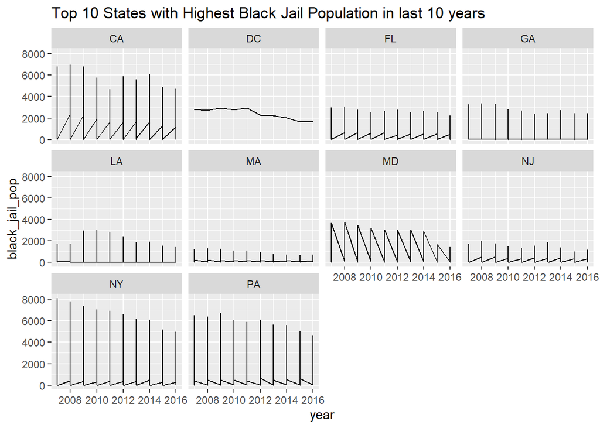

```r
library(ggplot2)
data2 <- data%>%
  filter(year != 3039, year > 2006, year < 2017, state %in% c("DC", "NJ", "FL", "CA", "MD", "LA", "NY", "MA", "PA","GA"))
ggplot(data2, aes(x = year, y = black_jail_pop )) +
  geom_line() +
  facet_wrap(~ state) +
  labs(title = "Top 10 States with Highest Black Jail Population in last 10 years")
```

From above line plots for different States, I observed that New York and California has highest Black Jail Population in last 10 years followed by Pennsylvania. From top 10 states Massachusetts has lowest Black Jail Population followed by New Jersey Louisiana.

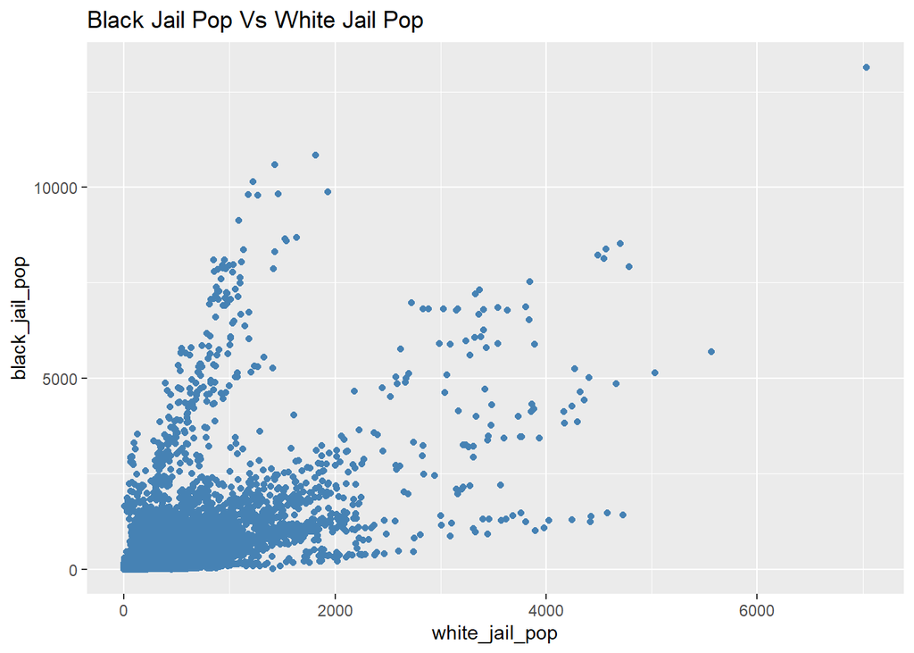

```r
ggplot(data, aes(x = white_jail_pop, y = black_jail_pop)) +
  geom_point(col = "steelblue") +
  labs(title = "Black Jail Pop Vs White Jail Pop")
```

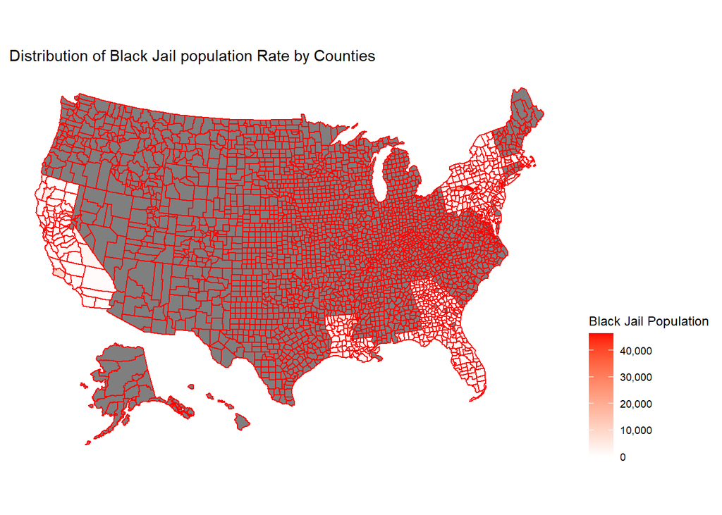

```r
library(usmap)
library(ggplot2)
library(plotly)
 plot_usmap(region = "counties", data = data2, values = "black_jail_pop_rate", color = "red") +
  scale_fill_continuous(
    low = "white", high = "red", name = "Black Jail Population", label = scales::comma
  ) +
   theme(legend.position = "right") +
   labs(title = "Distribution of Black Jail population Rate by Counties")
```